# Homework Chapter 2 - Mark Cappiello

1. Flip a fair coin nine times and write down the number of heads obtained. Now repeat this process 100,000 times. Obviously you don’t want to have to do that by hand, so create the necessary lines of R code to do it for you. Hint: You will need both the rbinom() function and the table() function. Write down the results and explain in your own words what they mean.

```r
results <- table(rbinom(n=100000,size=9,prob=0.5))

results
```

```
##
##     0     1     2     3     4     5     6     7     8     9
##   205  1797  6949 16385 24716 24522 16565  6891  1782   188
```

Explanation of the Code

Defining Variables in the rbinom function n = 100,000 (this is the number of trials in our binary distribution)

size = 9 (this is the number of events in each trial, in other words we will flip the coin 9 times in each trial)

prob = .5 (this is the probability that a fair coin will land on heads)

simulating the trials: The rbinom() function simulates 100,000 trials of flipping a coin 9 times each and counts the number of heads in each trial.

summarizing the results: The table() function creates a frequency table of the number of heads resultin from each trial.

2. Using the output from Exercise 1, summarize the results of your 100,000 trials of nine flips each in a bar plot using the appropriate commands in R. Convert the results to probabilities and represent that in a bar plot as well. Write a brief interpretive analysis that describes what each of these bar plots signifies and how the two bar plots are related. Make sure to comment on the shape of each bar plot and why you believe that the bar plot has taken that shape. Also make sure to say something about the center of the bar plot and why it is where it is.

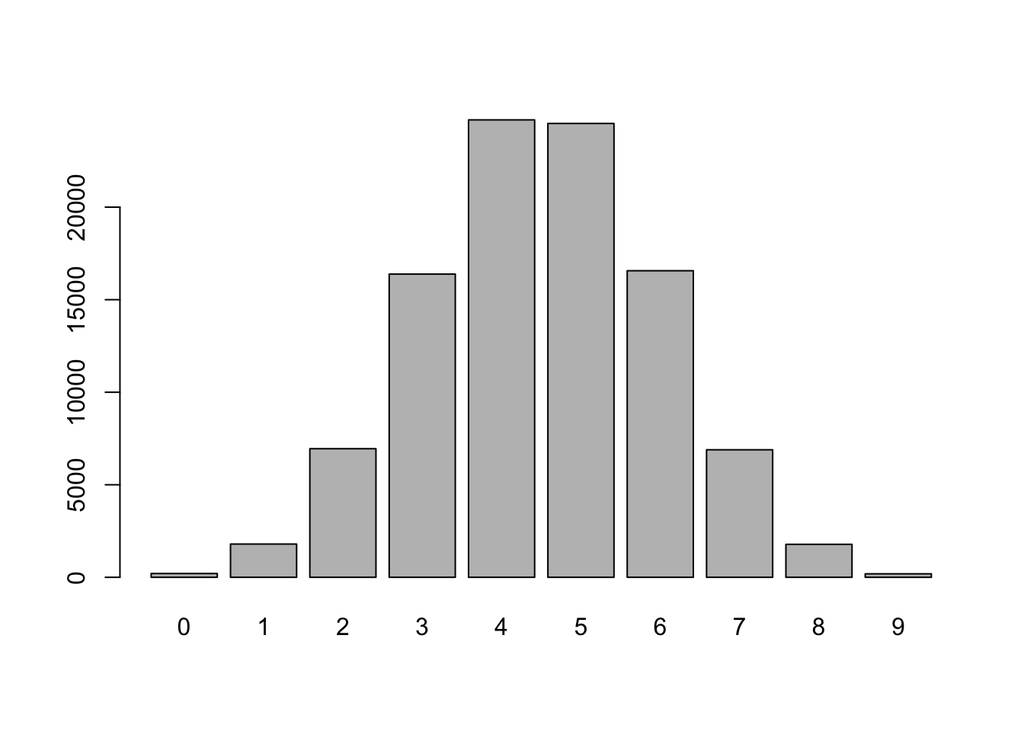

```r
barplot(results)
```

```r
probabilities <- results/1000

probabilities
```

```
##
##      0      1      2      3      4      5      6      7      8      9
##  0.205  1.797  6.949 16.385 24.716 24.522 16.565  6.891  1.782  0.188
```

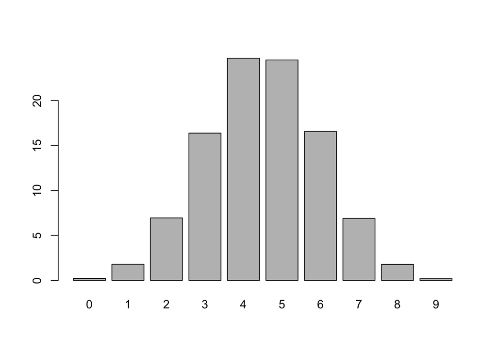

```r
barplot(probabilities)
```

6. One hundred students took a statistics test. Fifty of them are high school students and 50 are college students. Eighty students passed and 20 students failed. You now have enough information to create a two-by-two contingency table with all of the marginal totals specified (although the four main cells of the table are still blank). Draw that table and write in the marginal totals. I’m now going to give you one additional piece of information that will fill in one of the four blank cells: only three college students failed the test. With that additional information in place, you should now be able to fill in the remaining cells of the two-by-two table. Comment on why that one additional piece of information was all you needed in order to figure out all four of the table’s main cells. Finally, create a second copy of the complete table, replacing the counts of students with probabilities. What is the pass rate for high school students? In other words, if one focuses only on high school students, what is the probability that a student will pass the test?